# Rising Stars Muay Thai: Culminating Experience Project

Final Analysis & Recommendations Report — IBM 6800 — Dr. Kwok

Jarrod Griffin, Karima Ajahiou, Lydia Chen, Juan De La Cruz, Christian Gutierrez-Garcia, Bhamini Raghuram Pillai  
Faculty Advisor: Dr. Anthony Kim

2026-04-30

## The Story

**The Problem** → **What We Found** → **What To Do**

RSMT runs great events. We built the analytics infrastructure from scratch — website, tracking, data pipeline — then analyzed two full event cycles to answer one question: **who is our audience, how do we track them, and how do we reach more of them?**

## Zero Digital Foundation

**RSMT had no way to measure what was working.**

0 Dedicated website before this project

0 Analytics tracking or customer data

0 Data-driven campaigns or channel measurement

**Four revenue streams operating in the dark:**

**🎟 Live Tickets**Primary revenue — untracked funnel

**📺 Pay-Per-View**Digital revenue — no click tracking

**🥊 Gym Memberships**Long-term LTV — no conversion path

**🛍 Merchandise**Ancillary revenue — invisible to analytics

## What We Built

**The analytics pipeline — deployed from scratch:**

```
Instagram / Paid Ads / Organic Search
          │
          ▼
  www.risingstarsmuaythai.com
  (Google Tag Manager + GA4)
          │
          ▼  BigQuery export — event stream
  data/raw/ga4_events.parquet
          │
          ▼  DuckDB SQL · R statistical models
  Session models · Funnel analysis · Logistic regression
```

RSMT 14: Jan 31, 2026 · RSMT 15: Apr 18, 2026 · This analysis: Apr 30, 2026

**What we measured:**

3,843 Tracked sessions across two event cycles

6 California venue markets · ACS 2023 drive-time analysis

12 RSMT 15 Instagram posts scored for engagement

## Six Assessment Objectives

**AO1 — Website Optimization** *Bhamini* Optimize RSMT’s website to capture user data and increase conversions — addressing the foundational gap of no way to track behavior or guide users toward tickets, PPV, or memberships.

**AO2 — Audience Segmentation** *Lydia* Evaluate potential markets to identify where RSMT can scale events most effectively — prioritizing the market with the best audience size, purchasing power, and demographic alignment.

**AO3 — Social Media Engagement** *Christian* Examine engagement data across digital platforms to identify which content generates reactions, clicks, and purchase intent — understanding what to post, how often, and which styles perform best.

**AO4 — Customer Journey Mapping** *Jarrod* Establish GTM + GA4 tracking to map the customer journey from initial social media touchpoints to ticket or membership purchase — quantifying drop-off at key friction points.

**AO5 — Event-to-Membership Metrics** *Juan* Implement web analytics and integrated channel data to map the journey from initial touchpoint through membership purchase — identifying friction points and enabling data-driven interventions.

**AO6 — Fighter Engagement** *Karima* Analyze fighter Instagram posts using likes, comments, and an engagement score to evaluate performance across matchups — optimizing promotional strategy based on measurable engagement rather than assumptions.

# What the Data Revealed

## Finding 1: The Wrong Traffic Is Winning AO1 · AO3 · AO4

**Paid Social drives the most sessions to the site — but organic visitors engage 8× more and convert at higher rates.**

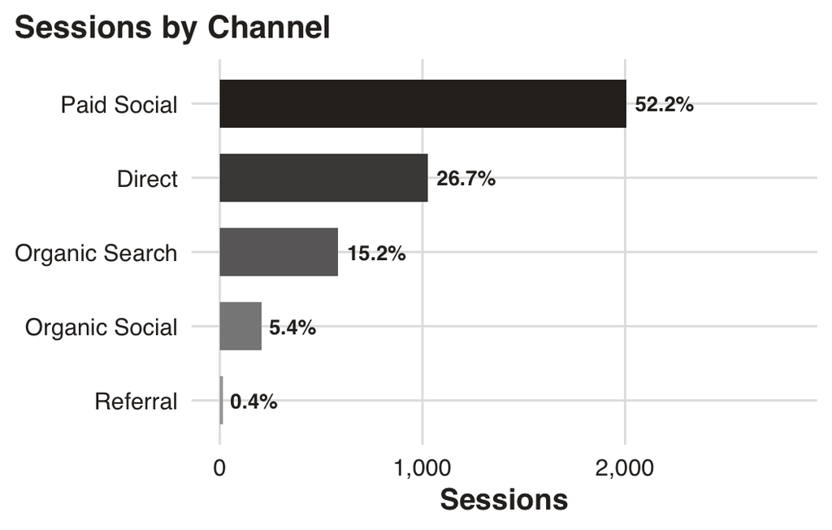

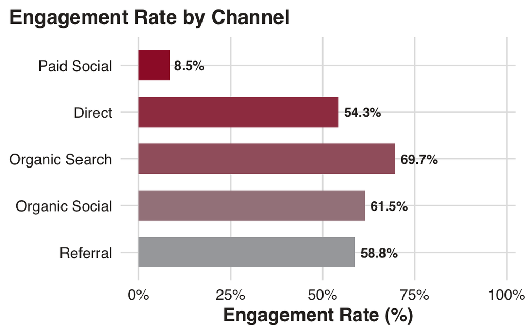

Paid Social = **most sessions, lowest engagement (8.5%)**. Organic Search = **fewer sessions, highest engagement (69.7%)**. Converted users browse **4.5 pages on average** vs 1.8 for non-converters — deeper engagement drives purchase, not traffic volume.

## Finding 2: Buyers Decide in One Session AO4 · AO5 · AO1

**Each additional page viewed multiplies conversion odds by 10.31×. And the homepage loses visitors in 6 seconds.**

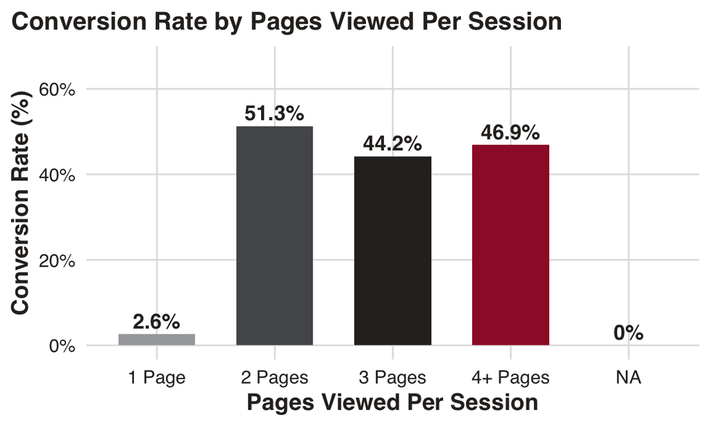

78.3% Complete the full journey — first visit to buy-link click — within a single session

90.6% Convert on the same calendar day as their very first touchpoint

10.31× Conversion odds per additional page viewed (logistic regression, McFadden R² = 0.274)

The homepage gets **1,212 views** but holds attention for just **~6 seconds** — only 175 visitors reach the event page, and 123 reach tickets. Yet the homepage drives **83% of all final conversion clicks**. Content pages build intent; the homepage must close it. Every friction point in the first visit is a permanently lost sale.

## Finding 3: Sacramento Has a Ceiling AO2

**Isochrone analysis across six California markets reveals a location gap.**

[interactive chart not shown]

12.96M Reachable audience within 60 min of Los Angeles

+309% More reachable people than Sacramento’s 3.1M baseline

51.1% Aged 18–54 in the LA catchment — the core ticket-buying demographic

$91,853 Median household income — supports premium pricing and larger venues

**Click any bubble** to see full market detail. Bubble size = reachable population within 60 minutes. Los Angeles isn’t just larger — income, age demographics, and census-tract coverage align closest to RSMT’s buyer profile. Full comparison in Appendix A.9.

## Finding 4: Followers Don’t Predict Activation AO6

**Koby Taylor (686 followers) outscored Vera Sokolova (2,450 followers) on every metric. Matchup excitement drives activation — not follower count.**

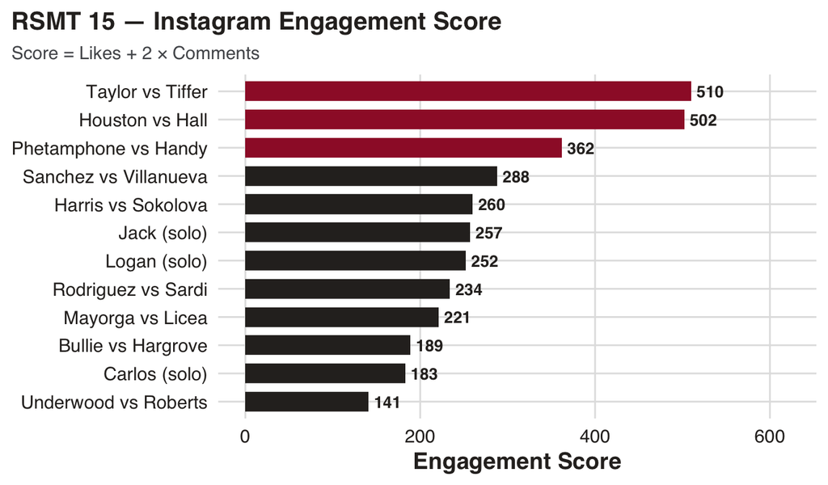

510 Taylor vs Tiffer — rank #1 · Koby Taylor: **686 followers**

502 Houston vs Hall — rank #2 · Darian Houston: **1,559 followers**

# Three Strategic Moves

## Move 1: Fix the Funnel AO1 · AO3 · AO4 · AO5

**The website must convert the traffic social media sends — and remove every friction point for the single-session buyer.**

**Add a “Buy Tickets” CTA above the fold**78% of buyers convert in one session with no return visit. The button must be visible without scrolling on mobile — the moment intent fires, there must be zero steps between it and a click.

**Route all social links directly to the event page**Instagram visitors currently land on the homepage and leave at 8.5% engagement. Sending them directly to the event page — not the generic homepage — shortens the path for followers who are already curious.

**Test mobile experience before every event cycle**90.6% of converters act on the day they first visit. Page load speed, sticky button visibility, and tap-target size on mobile should be verified in the two weeks before each event goes on sale.

## Move 2: Win on Organic Search AO4

**Organic Search is RSMT’s highest-converting channel. It’s also the one RSMT does nothing to capture.**

**Build fighter bios, event previews, and bout cards as indexed content**This is the same rich content that drives 4.5 page views per converting user. Building it for SEO serves double duty: search ranking and on-site intent formation. One well-written fighter profile earns traffic indefinitely — a paid impression expires in 24 hours.

**This is a first-mover opportunity**None of RSMT’s regional competitors — IKF Events, NAK Muay Challenge, or local MMA promotions — currently employ SEO-optimized content strategies. Consistent publishing before RSMT 16 and beyond would establish a measurable digital competitive advantage that is hard to replicate quickly.

## Move 3: Expand Smart AO2 · AO6

**Los Angeles gives RSMT 4× the audience. Engagement scoring tells RSMT who to put on the card.**

**Expand to Los Angeles:**

**Stage one LA event — test before committing to a full calendar**12.96M reachable people · +309% vs Sacramento · 51.1% aged 18–54 · $91,853 median income. The market can support premium pricing and larger venue capacity that Sacramento’s ceiling cannot.

**Target digital campaigns within the 60-minute drive catchment**The isochrone analysis identifies exactly where the audience clusters across 3,085 census tracts. Paid social and search campaigns should be geo-targeted to those areas — not broadcast broadly across the LA metro.

**Book fighters by data, not assumptions:**

**Headline Taylor vs Tiffer and Houston vs Hall at the next event**Engagement scores of 510 and 502. Koby Taylor (686 followers) outperformed Vera Sokolova (2,450 followers) on every metric. Follower count is not a reliable predictor — matchup excitement and comment activity are.

**Track engagement score every event cycle going forward**Build a data-driven promotional roster over time. Weight comments 2× more than likes when scoring: someone who wrote a sentence is more invested than someone who double-tapped. Use this score as the promotional and booking criterion — not gut feel.

## Three Things to Remember

1 Your buyers decide in **one session**. Fix the homepage CTA and mobile experience first — there is almost never a second visit.

2 Social media **gets them there**. Your website must **convert them**. Shift investment from volume (Paid Social) to intent (Organic Search and content).

3 Los Angeles is your **growth market**. Engagement scoring is your **booking tool**. Both are first-mover opportunities no regional competitor has claimed.

**The overarching implication:** RSMT has proven it can build an audience with high intent that acts quickly. The only remaining constraint is removing friction between discovery and purchase — and scaling into a market where that audience is four times larger.

## Thank You — Questions?

**Team**

Bhamini Raghuram Pillai — AO1: Website

Lydia Chen — AO2: Segment Market Expansion

Christian Gutierrez-Garcia — AO3: Social Media

Jarrod Griffin — AO4: Customer Journey

Juan De La Cruz — AO5: Membership Conversion

Karima Ajahiou — AO6: Fighter Engagement

**Key numbers**

# Appendix

Supporting detail — available for Q&A  
**A.1** Data Sources · **A.2** Technology Stack · **A.3** Conversion Definition  
**A.4** Regression Full Output · **A.5** Channel Performance Table · **A.6** Page Funnel  
**A.7** Last-Touch Before Conversion · **A.8** Journey Distribution  
**A.9** All Six Markets · **A.10** All Fighter Rankings · **A.11** Traffic Sources · **A.12** Limitations

## A.1 — Data Sources & Collection

| Source | Dataset | Coverage | Key Variables |
| --- | --- | --- | --- |
| **GA4 (event stream)** | `ga4_events.parquet` | RSMT 13 launch → Apr 30, 2026 | event_name · page_location · link_url · user_pseudo_id · ga_session_id · device_category · traffic_medium |
| **GA4 Data API** | `ga4_api_channel_acq.parquet` | All-time channel-level aggregates | sessionDefaultChannelGroup · sessions · engagementRate |
| **Google BigQuery** | Raw streaming export | Full event stream, lossless | Complete GA4 schema, exported via `bigrquery` R package |
| **ACS 2023 Census** | 60-min isochrone (6 venues) | Census tract 5-yr estimates | population · median_income · pct_age_18–34 · pct_age_35–54 · census_tracts |
| **Instagram (manual)** | RSMT 15 promo posts | 12 matchup posts | likes · comments · engagement_score = likes + 2×comments |

**Collection context:** Google Tag Manager and GA4 were deployed from scratch in late 2025. RSMT had zero analytics infrastructure before this project. BigQuery streaming export began at site launch and is continuous.

## A.2 — Technology Stack

**Tracking & Ingestion**

| Tool | Purpose |
| --- | --- |
| Google Tag Manager | Event triggers, custom tag deployment |
| Google Analytics 4 | Behavioral event collection |
| Google BigQuery | Cloud warehouse + raw export |
| `bigrquery` (R) | BigQuery API auth & pull |

**Storage & Query**

| Tool | Purpose |
| --- | --- |
| Apache Parquet + `arrow` | Columnar in-memory format |
| DuckDB + `DBI` | SQL over Parquet, no server needed |

**Analysis & Modeling**

| Package | Use |
| --- | --- |
| `dplyr` | Data wrangling (lazy eval over Arrow) |
| `ggplot2` | Publication-quality charts |
| `forcats`, `scales` | Factor ordering, number formatting |
| `stats::glm()` | Logistic regression (base R) |

**Reporting & Output**

| Tool | Purpose |
| --- | --- |
| Quarto | Reproducible documents & slides |
| RevealJS | HTML presentation engine |
| Posit Connect Cloud | Shiny app (AO2 census map) |
| Excel + Tableau | AO6 Instagram engagement scoring |

## A.3 — Conversion: How We Measured It

**A session is counted as a conversion when it contains at least one of:**

**Page view → `/go/tickets` or `/go/ppv`**RSMT redirect slugs. GA4 fires the page_view event before the external redirect fires, capturing the click-through moment. Both ticket and PPV paths are captured.

**Outbound click → `eventbrite.com`**Live ticket purchase platform. Tracked via GA4 outbound link event + GTM click trigger on the purchase button element.

**Outbound click → `akaizosports.live`**Pay-Per-View streaming platform. Same GTM click-tracking mechanism as Eventbrite.

**What this captures:**

High intentA visitor who clicked to the purchase platform — the strongest measurable signal short of a post-purchase pixel

**What this does NOT capture:**

- Confirmed transactions (no Eventbrite pixel)
- Users who typed the URL directly after leaving
- In-person or phone ticket sales

**Key implication:** All conversion rates here are **lower bounds**. True conversion rate is higher. A post-purchase pixel for RSMT 16 would close this gap and enable confirmed-purchase measurement.

## A.4 — Logistic Regression: Full Model Output

**Model:** `glm(conversion_flag ~ session_event_count + page_view_count + device_category + traffic_medium, family = binomial)` · **McFadden R²:** 0.274 · **N:** 1,433 sessions

| Predictor | Odds Ratio | 95% CI | p-value |  |
| --- | --- | --- | --- | --- |
| (Intercept) | 0.044 | 0.026 – 0.076 | < 0.001 | *** |
| session_event_count | 0.488 | 0.426 – 0.56 | < 0.001 | *** |
| page_view_count | 10.306 | 7.078 – 15.008 | < 0.001 | *** |
| device_categorymobile | 0.778 | 0.48 – 1.26 | 0.3076 |  |
| device_categorytablet | 0.000 | 0 – Inf | 0.977 |  |
| traffic_mediumorganic | 1.634 | 1.154 – 2.314 | < 0.01 | ** |
| traffic_mediumpaid | 0.270 | 0.166 – 0.439 | < 0.001 | *** |
| traffic_mediumreferral | 0.365 | 0.116 – 1.144 | 0.0838 |  |
| traffic_mediumsocial | 1.199 | 0.326 – 4.406 | 0.7845 |  |

Reference category: desktop device · cpc (paid social) medium. Intercept OR reflects baseline log-odds and is not standalone-interpretable. *** p<0.001 · ** p<0.01 · * p<0.05

## A.5 — Channel Performance: Complete Table

**All acquisition channels — sessions, % of total traffic, and engagement rate**

| Channel | Sessions | % of Total | Engagement Rate |
| --- | --- | --- | --- |
| Paid Social | 2,006 | 52.2% | 8.5% |
| Direct | 1,027 | 26.7% | 54.3% |
| Organic Search | 585 | 15.2% | 69.7% |
| Organic Social | 208 | 5.4% | 61.5% |
| Referral | 17 | 0.4% | 58.8% |

Source: GA4 Data API (ga4_api_channel_acq.parquet). Unassigned and (other) excluded. Engagement rate = sessions containing ≥1 engaged event ÷ total sessions.

## A.6 — Page Funnel: Every Number

**Homepage → Event Page → Ticket Page — full metrics from GA4 Pages & Screens**

[output not shown]

**Homepage first-step navigation (Path Exploration · 1,028 homepage sessions):**

| Immediate next page from homepage | Users |
| --- | --- |
| PPV page | 122 |
| Ticket page | 101 |
| Event page | 78 |
| Exit / bounce | remaining majority |

Source: GA4 Pages & Screens report + Path Exploration tool. 30-day window ending Apr 30, 2026.

## A.7 — Last Page Before Conversion (Full)

**Page visited immediately before the buy-link click — all categories**

| Page Category (last before conversion click) | Conversions | % of Total |
| --- | --- | --- |
| Home Page | 187 | 82.7 |
| Events Page | 20 | 8.8 |
| Dedicated Tickets/PPV Page | 18 | 8.0 |
| Fighter Profile | 1 | 0.4 |

The homepage triggers the most final conversions despite being the page with the shortest dwell time. It functions as a **closing page**: content pages (fighters, fight card) build intent; the homepage must execute the purchase click. A sticky “Buy Tickets” CTA above the fold converts this already-warm traffic with zero additional friction.

## A.8 — User Journey: Days & Sessions to Conversion

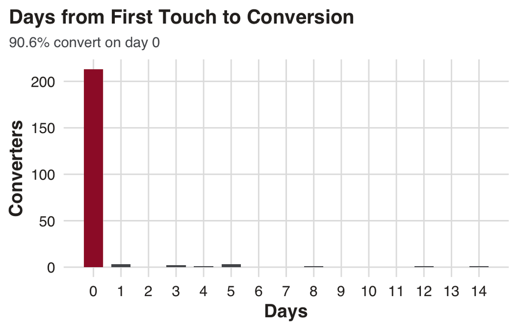

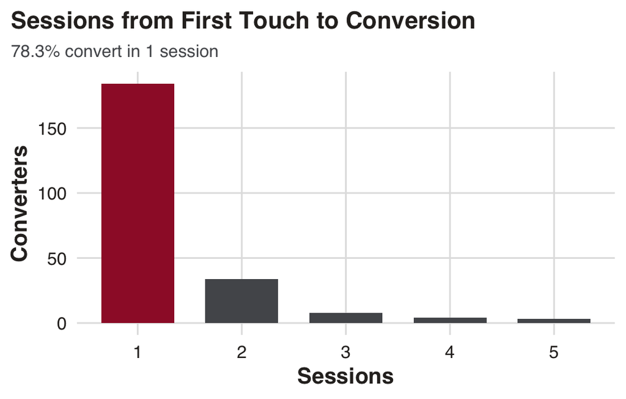

Converters beyond 14 days or 5 sessions represent a small tail and are excluded here for readability.

## A.9 — All Six Markets: Full Comparison (AO2)

**ACS 2023 · 60-minute drive-time isochrone · candidate venue addresses**

| Market | Census Tracts | Reachable Pop. | Median HH Income | Age 18–54 | Pop Δ vs Sacramento |
| --- | --- | --- | --- | --- | --- |
| Sacramento *(baseline)* | 711 | 3,166,025 | $89,844 | 48.3% | — |
| San Jose | 1,124 | 5,014,076 | $147,459 | 50.7% | +58.4% |
| San Francisco | 1,232 | 5,249,936 | $143,095 | 50.1% | +65.8% |
| Riverside | 1,658 | 8,207,709 | $94,760 | 49.5% | +159.2% |
| **Los Angeles** | **3,085** | **12,960,180** | **$91,853** | **51.1%** | **+309.4%** |
| Anaheim | 3,044 | 13,203,228 | $90,893 | 51.3% | +316.9% |

**Why Los Angeles over Anaheim** (Anaheim is marginally larger by population):

- Higher median income ($91,853 vs $90,893) → stronger premium ticket potential
- More census tracts (3,085 vs 3,044) → broader geographic audience spread
- Higher existing social media presence (20 tracked website users vs 13 in Anaheim)
- Venue: 1111 S Figueroa St (Crypto.com Arena area) vs 2695 E Katella Ave (Honda Center)

Source: ACS 2023 5-year estimates, Census Bureau. Drive-time isochrones generated at the census-tract level. Age 18–54 = pct_age_18–34 + pct_age_35–54.

## A.10 — All 12 Fighter Matchups: Complete Rankings (AO6)

**RSMT 15 Instagram promotional posts · Engagement Score = Likes + 2 × Comments**

| Rank | Matchup / Post | Likes | Comments | Engagement Score |
| --- | --- | --- | --- | --- |
| 1 | Taylor vs Tiffer | 428 | 41 | 510 |
| 2 | Houston vs Hall | 420 | 41 | 502 |
| 3 | Phetamphone vs Handy | 288 | 37 | 362 |
| 4 | Sanchez vs Villanueva | 268 | 10 | 288 |
| 5 | Harris vs Sokolova | 246 | 7 | 260 |
| 6 | Jack (solo) | 197 | 30 | 257 |
| 7 | Logan (solo) | 206 | 23 | 252 |
| 8 | Rodriguez vs Sardi | 206 | 14 | 234 |
| 9 | Mayorga vs Licea | 201 | 10 | 221 |
| 10 | Bullie vs Hargrove | 163 | 13 | 189 |
| 11 | Carlos (solo) | 135 | 24 | 183 |
| 12 | Underwood vs Roberts | 113 | 14 | 141 |

## A.11 — AO3: Traffic Sources + AO5: Conversion Timing

**AO3 — Traffic Source Breakdown (total events)**

| Source | Events |
| --- | --- |
| google | 1,946 |
| (direct) | 1,894 |
| ig *(Instagram in-app)* | 634 |
| bing | 71 |
| yahoo | 40 |
| facebook.com | 30 |
| lm.facebook.com | 30 |
| duckduckgo | 26 |
| l.instagram.com | 19 |
| m.facebook.com | 11 |
| l.facebook.com | 5 |
| ecosia.org | 4 |
| instagram.com | 4 |
| chatgpt.com | 2 |
| linktr.ee | 2 |

Total page views: **2,668** · Unique users: **1,095** · Avg: **2.44 pages/user**

**AO5 — High-Intent Conversion Timing**

85.9% Same-day: reach a high-intent page (`/events/`) on the same calendar day as first visit

82.4% Single-session: reach a high-intent page within the same browsing session as first touch

**AO5 Method:** Conversion = first visit to `/events/` page. First-touch date vs. conversion date across multiple months of data. Pattern is **consistent across all months** — not event-specific noise.

**Implication:** Direct social and email links to `/events/` pages (not the homepage) shorten the path to high-intent behavior where purchase intent is already forming.

## A.12 — Study Limitations & RSMT 16 Outlook

**Known limitations:**

**Click intent ≠ confirmed purchase**We measure redirect clicks to Eventbrite/Akaizo. The gap between click and confirmed transaction is unknown without a post-purchase pixel. All conversion rates are lower bounds.

**Two event cycles = directional, not causal**RSMT 14 (Jan 31) and RSMT 15 (Apr 18) establish behavioral patterns. Causal claims need more cycles and controlled variation — these findings should seed experiments, not replace them.

**No demographic data on site visitors**GA4 does not surface age/gender in this export. Demographic findings (51% age 18–54) come from ACS Census at the market level — not from actual visitor profiles.

**What RSMT 16 data adds:**

**Third cycle → trend validation**Three data points confirm whether channel and funnel patterns are stable across events. RSMT 16 is the first real test of whether these findings are systematic — not event-specific.

**Pre/post optimization comparison**If homepage CTA and direct social links are implemented before RSMT 16, the data will directly measure impact — converting these recommendations from theoretical to evidenced.

**Longitudinal fighter engagement baseline**Three events of Instagram scoring data builds a fighter performance ranking over time — not a single-event snapshot. More reliable as a booking and promotion criterion.